# Data Analysis and Exploration with R: A Crash Course (Chapter 3)

Faustino Delgado Camacho

August 2022, V2 (english version)

# Chapter 3: Loop functions: The `apply` Family

As we saw in previous chapters, the peculiar nature of R suggests not making use of loops in all situations where an iteration of instructions is required; We have already seen that we can take advantage of the native vectorization of R, but there are also functions that can *cycle* instructions in a more *pleasant* way, either on simple or more complex data structures.

The `apply()` family of functions belongs to the base R package, and has functions to manipulate slices of matrices, `arrays`, lists and `data.frames` iteratively.

These functions allow you to cross-operate on the data in various ways and avoid the explicit use of loops. These functions act on an input structure and apply a function with one or more optional arguments.

The types of functions that can be looped are:

- Aggregation functions, for example the average or the sum.
- Functions of transformation or creation of subsets.
- Vectorized functions that produce more complex structures.
- Functions defined or created by the user.

Chapter contents

- 3.1 The `apply()` function
- 3.2 The `lapply()` function
- 3.3 The `sapply()` function
- 3.4 The `mapply()` function
- 3.5 The `vapply()` function
- 3.6 The `tapply()` function
- 3.7 The `rapply()` function
- 3.8 Wrap-up

The `apply()` functions form the basis for more complex combinations and help to perform operations with very few lines of code. The family consists of the functions `apply()`, `lapply()`, `sapply()`, `vapply()`, `mapply()`, `rapply()`, and `tapply()`.

### 3.1 The `apply()` function

The `apply()` function operates on `arrays`. For simplicity, we will focus on 2-dimensional `arrays`, which are also known as matrices.

The syntax is:

```r
# apply(X,
#       MARGIN,
#       FUN,
#       ...)
```

Where:

- `X` is an `array`, or a matrix, `data.frames` are also accepted.
- `MARGIN` is a variable that defines how the function is applied: when `MARGIN = 1`, it is applied on rows (`i`), while with `MARGIN = 2`, it works on columns (`j`). When you use the `MARGIN = c (1,2)` construct, it applies to both rows and columns (`i,j`).
- `FUN` is the function you want to apply to these structures.

Now we are going to see how to get the average of columns and the sum of rows of a matrix:

```r
set.seed(1)

x<-matrix(round(rnorm(500),3),
                              # Create matrix( of 500 elements with normal distribution,
          nrow=100,           # Distributed in 100 rows and 5 columns)
          ncol=5)
                              # The round() function, limits the number of decimals,
                              # in this case, the limit is 3 decimals

head(x)
```

```
##        [,1]   [,2]   [,3]   [,4]   [,5]
## [1,] -0.626 -0.620  0.409  0.894  1.074
## [2,]  0.184  0.042  1.689 -1.047  1.896
## [3,] -0.836 -0.911  1.587  1.971 -0.603
## [4,]  1.595  0.158 -0.331 -0.384 -0.391
## [5,]  0.330 -0.655 -2.285  1.654 -0.416
## [6,] -0.820  1.767  2.498  1.512 -0.376
```

```r
round(apply(x, 2, mean),3)    # apply to (x, on columns, the function "mean()")
```

```
## [1]  0.109 -0.038  0.030  0.052 -0.039
```

```r
# We manually check the mean of some column

round(mean(x[,1]),3)
```

```
## [1] 0.109
```

```r
y<-apply(x, 1, sum)     # apply to (x, on rows, the function "sum()")

# visualize
cbind(head(x),sum=y[1:6])
```

```
##                                            sum
## [1,] -0.626 -0.620  0.409  0.894  1.074  1.131
## [2,]  0.184  0.042  1.689 -1.047  1.896  2.764
## [3,] -0.836 -0.911  1.587  1.971 -0.603  1.208
## [4,]  1.595  0.158 -0.331 -0.384 -0.391  0.647
## [5,]  0.330 -0.655 -2.285  1.654 -0.416 -1.372
## [6,] -0.820  1.767  2.498  1.512 -0.376  4.581
```

```r
# We manually check the sum of some row

sum(x[1,])
```

```
## [1] 1.131
```

### 3.2 The `lapply()` function

The `lapply()` function is useful for performing operations on lists, and returns a list with the same length as the original set. Each element of the resulting list is the result of applying a function, defined by `FUN`, to the corresponding element of the list `X`. It can also accept `data.frames` or `vectors`, but the result will be a list.

Syntax

```r
# lapply(X,
#        FUN)
```

Example 1: Convert all uppercase words within the vector `movies`, to lowercase words.

```r
movies <- c("AVENGERS","JOKER","BRAVE","UP")

movies_lowercase <-lapply(movies, tolower)

str(movies_lowercase)
```

```
## List of 4
##  $ : chr "avengers"
##  $ : chr "joker"
##  $ : chr "brave"
##  $ : chr "up"
```

```r
# We can use the "unlist()" function to transform the result of "lapply()" to a vector.

movies_lowercase <-unlist(lapply(movies,tolower))

str(movies_lowercase)
```

```
##  chr [1:4] "avengers" "joker" "brave" "up"
```

Example 2: Extract the second column of all arrays within the `mat.l` list, and assign them to `mat.l.col2`, and extract the second row of all arrays within the `mat.l` list and assign them to `mat.l.row2`

```r
mat.l<-list("A"=matrix(1:9,nrow=3,ncol=3),
            "B"=matrix(11:26,nrow=4,ncol=4),
            "C"=matrix(31:34,nrow=2,ncol=2))

mat.l.col2<-lapply(mat.l,function(x) x[,2])

mat.l.row2<-lapply(mat.l,function(x) x[2,])

mat.l
```

```
## $A
##      [,1] [,2] [,3]
## [1,]    1    4    7
## [2,]    2    5    8
## [3,]    3    6    9
##
## $B
##      [,1] [,2] [,3] [,4]
## [1,]   11   15   19   23
## [2,]   12   16   20   24
## [3,]   13   17   21   25
## [4,]   14   18   22   26
##
## $C
##      [,1] [,2]
## [1,]   31   33
## [2,]   32   34
```

```r
str(mat.l.col2)
```

```
## List of 3
##  $ A: int [1:3] 4 5 6
##  $ B: int [1:4] 15 16 17 18
##  $ C: int [1:2] 33 34
```

```r
str(mat.l.row2)
```

```
## List of 3
##  $ A: int [1:3] 2 5 8
##  $ B: int [1:4] 12 16 20 24
##  $ C: int [1:2] 32 34
```

```r
unlist(mat.l.col2)
```

```
## A1 A2 A3 B1 B2 B3 B4 C1 C2
##  4  5  6 15 16 17 18 33 34
```

```r
unlist(mat.l.row2)
```

```
## A1 A2 A3 B1 B2 B3 B4 C1 C2
##  2  5  8 12 16 20 24 32 34
```

### 3.3 The `sapply()` function

The `sapply()` function does the same job as the `lapply()` function, but can return a simpler structure, such as a vector, if the output of the `FUN` function allows it, i.e. it *simplifies* the *output* that could be obtained with `lapply()`.

Syntax

```r
# sapply(X,
#        FUN)
```

Returning to ‘Example 1’ of the `lapply()` function: Convert all uppercase words in the `movies` vector to lowercase words.

```r
movies <- c("AVENGERS","JOKER","BRAVE","UP")
movies_lowercase <-as.character(sapply(movies,
                                    tolower))

str(movies_lowercase)
```

```
##  chr [1:4] "avengers" "joker" "brave" "up"
```

Example 2: Extract the element of the second row and second column from all arrays in `mat.l` and assign them to mat.l.row2col2.

```r
(mat.l<-list("A"=matrix(1:9,nrow=3,ncol=3),
            "B"=matrix(11:26,nrow=4,ncol=4),
            "C"=matrix(31:34,nrow=2,ncol=2)))
```

```
## $A
##      [,1] [,2] [,3]
## [1,]    1    4    7
## [2,]    2    5    8
## [3,]    3    6    9
##
## $B
##      [,1] [,2] [,3] [,4]
## [1,]   11   15   19   23
## [2,]   12   16   20   24
## [3,]   13   17   21   25
## [4,]   14   18   22   26
##
## $C
##      [,1] [,2]
## [1,]   31   33
## [2,]   32   34
```

```r
mat.l.row2col2<-sapply(mat.l,function(x) x[2,2])

str(mat.l.row2col2)
```

```
##  Named int [1:3] 5 16 34
##  - attr(*, "names")= chr [1:3] "A" "B" "C"
```

### 3.4 The `mapply()` function

The `mapply()` function is a multi-variable version of `sapply()`, it applies the `FUN` function to the elements with index *i* of each `var n` argument. The arguments are recycled if necessary.

Syntax

```r
# mapply(FUN,
#        var 1...var n)
```

Example 1: Sum of the `i` elements of `n` vectors:

```r
mapply(sum,    # "mappply" addition to 3 vectors with a sequence from 1 to 5
       1:5,    # i.e: 1+1+1, 2+2+2, etc.
       1:5,
       1:5)
```

```
## [1]  3  6  9 12 15
```

```r
# This is basically the same as:
1:5+1:5+1:5
```

```
## [1]  3  6  9 12 15
```

```r
# If we made a matrix with the same values spread over 3 columns:
x<-matrix(c(rep(1:5,3)),
          nrow=5,
          ncol=3)

x
```

```
##      [,1] [,2] [,3]
## [1,]    1    1    1
## [2,]    2    2    2
## [3,]    3    3    3
## [4,]    4    4    4
## [5,]    5    5    5
```

```r
# We would get the same result if:
apply(x,1,sum)
```

```
## [1]  3  6  9 12 15
```

Example 2: Evaluate if each column of `x` is identical to each column of `y`.

```r
x<-data.frame(V1=c(1:5),
              V2=c(6:10),
              V3=c(11:15))

y<-data.frame(V1=c(1:5),
              V2=c(6:10),
              V3=c(11:14,16))
# Look at the output of the "identical()" function
#   Note: identical() only works if both tables have the same dimensions
#          and column names.
identical(x,y)
```

```
## [1] FALSE
```

```r
# We know that in general, x is not identical to y, but we want
# to know which column is different.

mapply(identical,x,y)
```

```
##    V1    V2    V3
##  TRUE  TRUE FALSE
```

```r
data.frame(identical_x_vs_y=mapply(identical,x,y))
```

```
##    identical_x_vs_y
## V1             TRUE
## V2             TRUE
## V3            FALSE
```

### 3.5 The `vapply()` function

The `vapply()` function is a stricter version of `sapply()`, it applies the `FUN` function to the elements of `X`, but one must indicate the amount and kind of *output* that is expected in `FUN.VALUE`, we could think of `vapply` as a `sapply` with *output* validation.

Syntax

```r
# vapply(X,
#        FUN,
#        FUN.VALUE=class of output (length of output))
```

To see how it works, it’s useful to compare it to `sapply`.

```r
set.seed(100)
dat<-data.frame(X=rnorm(n=100,     # We create a data.frame with 3 columns (X,Y,Z)
                        mean=0,    # Each one composed of 100 obs. with normal
                        sd=1),     # distribution, different means, same std.
                Y=rnorm(n=100,
                        mean=1,
                        sd=1),
                Z=rnorm(n=100,
                        mean=2,
                        sd=1))

sapply(dat,mean)
```

```
##           X           Y           Z
## 0.002912563 1.011140837 2.012793127
```

```r
# In this case, we expect the output to be of class "numeric", length=1
vapply(dat,mean,numeric(1))
```

```
##           X           Y           Z
## 0.002912563 1.011140837 2.012793127
```

```r
# Notice what happens when we define the length of the output to 2.


vapply(dat,mean,numeric(2))
```

```
## Error in vapply(dat, mean, numeric(2)): values must be length 2,
##  but FUN(X[[1]]) result is length 1
```

```r
# Basically R is telling you, that an output of 2 numbers was expected for each i,
# but the operation returned 1 for each i

# Now, by applying the summary() function to each column, we expect an output
# of length 6 for each i.

vapply(dat,summary,numeric(6))
```

```
##                    X          Y         Z
## Min.    -2.271925486 -1.1364939 -1.020814
## 1st Qu. -0.608846594  0.5681700  1.394084
## Median  -0.059419897  0.9271222  2.159128
## Mean     0.002912563  1.0111408  2.012793
## 3rd Qu.  0.655891078  1.4461908  2.657317
## Max.     2.581958928  3.1686003  4.727888
```

```r
# The summary() function acts in different ways, depending
# on the class to which it is applied in this case, because the class is "numeric",
# it returns a statistical summary of the columns.


t(vapply(dat,summary,numeric(6)))
```

```
##        Min.    1st Qu.     Median        Mean   3rd Qu.     Max.
## X -2.271925 -0.6088466 -0.0594199 0.002912563 0.6558911 2.581959
## Y -1.136494  0.5681700  0.9271222 1.011140837 1.4461908 3.168600
## Z -1.020814  1.3940839  2.1591282 2.012793127 2.6573168 4.727888
```

```r
# The "t()" function is used to transpose matrices, transpose means
# that we are going to exchange rows for columns, and vice versa.
# Some sort of dimensional rotation.
```

### 3.6 The `tapply()` function

The `tapply()` function is useful when we need to partition a vector into groups defined by some `INDEX` sorting or grouping factor, compute a `FUN` function on the generated subsets over `X`, and return the results in a convenient way.

Syntax

```r
# tapply(X,
#        INDEX,
#        FUN)
```

Where:

- `X` is the variable on which the `FUN` function must be applied.
- `INDEX` is the grouping variable.

Example:

```r
set.seed(200)

# We create a data set, where we simulate the effect of diet and physical training in
# people with morbid obesity.

# We create the variable to control the number of samples
np=4*100 #number of patients

weight_control<-data.frame(patient_id = as.character(paste0("patient_", 1:np)),
                    age_years = as.integer(round(rnorm(np, mean = 50, sd =8),
                                                 digits = 0)),
                    starting_weight_kg=rnorm(np,300,10),
                    final_weight_kg = c(rnorm(np/4,mean=100,sd=10),
                                     rnorm(np/4,mean=70,sd=5),
                                     rnorm(np/4,mean=90,sd=5),
                                     rnorm(np/4,mean=300,sd=10)),
                   height_m=rnorm(np, mean = 1.75, sd =0.08),
                    gender_binary=as.factor(rep_len(c("f","m"),
                                          np)),
                    treatment_category = gl(4,
                                            np/4,
                                     labels = c("diet",
                                                "diet_and_physical_training",
                                                "physical_training",
                                                "control")))


# The function "gl()" generates a vector of factors defined
# by (n levels, n members x level, level labels)


## Feature engineering

# Starting and final bmi calculations

weight_control$starting_bmi<-weight_control$starting_weight_kg/(weight_control$height_m**2)
weight_control$final_bmi<-weight_control$final_weight_kg/(weight_control$height**2)

# Starting and final bmi classification
#  We create a function that helps us do
#  the classification automatically.

BMI_classifier<-function(x){
  as.factor(ifelse(x<18.5,"low_weight",
                   ifelse(x>=18.5 &
                            x<25,"normal_weight",
                          ifelse(x>=25 &
                                   x<30,"overweight",
                                 ifelse(x>=30 &
                                          x<35,"mild_obesity",
                                        ifelse(x>=35 &
                                                 x<40,"obesity",
                                               "morbid_obesity"))))))
}

weight_control$starting_bmi_category<-BMI_classifier(weight_control$starting_bmi)


weight_control$final_bmi_category<-BMI_classifier(weight_control$final_bmi)

# Calculation of differences (deltas)

weight_control$delta_weight_kg<-weight_control$starting_weight_kg-weight_control$final_weight_kg

weight_control$delta_bmi<-weight_control$starting_bmi-weight_control$final_bmi


# Generate a data summary
summary(weight_control)
```

```
##   patient_id          age_years     starting_weight_kg final_weight_kg
##  Length:400         Min.   :28.00   Min.   :270.2      Min.   : 59.32
##  Class :character   1st Qu.:45.00   1st Qu.:293.4      1st Qu.: 81.49
##  Mode  :character   Median :50.00   Median :299.9      Median : 93.64
##                     Mean   :50.12   Mean   :299.7      Mean   :140.58
##                     3rd Qu.:55.00   3rd Qu.:306.2      3rd Qu.:159.68
##                     Max.   :80.00   Max.   :325.3      Max.   :322.56
##     height_m     gender_binary                  treatment_category
##  Min.   :1.549   f:200         diet                      :100
##  1st Qu.:1.697   m:200         diet_and_physical_training:100
##  Median :1.753                 physical_training         :100
##  Mean   :1.754                 control                   :100
##  3rd Qu.:1.805
##  Max.   :2.005
##   starting_bmi      final_bmi         starting_bmi_category
##  Min.   : 70.32   Min.   : 17.60   morbid_obesity:400
##  1st Qu.: 91.34   1st Qu.: 26.21
##  Median : 97.55   Median : 30.92
##  Mean   : 98.10   Mean   : 45.81
##  3rd Qu.:104.60   3rd Qu.: 57.12
##  Max.   :130.09   Max.   :124.41
##       final_bmi_category delta_weight_kg    delta_bmi
##  low_weight    :  4      Min.   :-39.08   Min.   :-12.76
##  mild_obesity  : 84      1st Qu.:139.79   1st Qu.: 40.19
##  morbid_obesity:103      Median :204.81   Median : 65.62
##  normal_weight : 77      Mean   :159.15   Mean   : 52.29
##  obesity       : 33      3rd Qu.:219.04   3rd Qu.: 73.38
##  overweight    : 99      Max.   :261.37   Max.   :100.78
```

```r
# We want to EXPLORE if the treatments had any indication of effect

treatment_effects<-tapply(weight_control$final_bmi,           # X
                          weight_control$treatment_category,  # INDEX
                          summary)                            # FUN

treatment_effects
```

```
## $diet
##    Min. 1st Qu.  Median    Mean 3rd Qu.    Max.
##   24.31   29.54   31.96   32.46   35.49   49.87
##
## $diet_and_physical_training
##    Min. 1st Qu.  Median    Mean 3rd Qu.    Max.
##   17.60   21.33   23.28   23.43   25.11   30.32
##
## $physical_training
##    Min. 1st Qu.  Median    Mean 3rd Qu.    Max.
##   23.66   27.47   29.89   29.99   32.21   39.12
##
## $control
##    Min. 1st Qu.  Median    Mean 3rd Qu.    Max.
##   78.84   91.15   96.83   97.35  103.39  124.41
```

```r
treatment_effects.df<- do.call(rbind,               # Function
                                 treatment_effects) # Argument list

treatment_effects.df
```

```
##                                Min.  1st Qu.   Median     Mean   3rd Qu.
## diet                       24.31047 29.53742 31.96384 32.46227  35.48720
## diet_and_physical_training 17.60446 21.32765 23.28333 23.43037  25.11293
## physical_training          23.66123 27.46616 29.88690 29.98649  32.21126
## control                    78.84499 91.14723 96.83323 97.35062 103.39297
##                                 Max.
## diet                        49.87335
## diet_and_physical_training  30.31577
## physical_training           39.11740
## control                    124.40778
```

```r
# The "do.call()" function allows you to call any function in R,
# but instead of writing the arguments one by one, you can use
# a list to hold the function's arguments.
# do.call() is another loop function.
```

### 3.7 The `rapply()` function

The `rapply()` function stands for *recursive apply*, and as its name suggests, it is used to apply an `f` function to all elements of `object` recursively. The `classes` argument delimits the elements on which the `f` function is going to be applied, based on their class.

This function has three basic modes. If `how = "replace"`, each element of `object` that has its class included in `classes` is replaced by the result of applying `f` to the element in question.

With the `how = "list"` mode, all elements that have a class included in `classes` are replaced by the result of applying `f` to the element, and all others are replaced by default result `deflt`.

Next, if `how = "unlist"`, `unlist (recursive = TRUE)` is invoked on the result.

Finally, in `...` you put any extra arguments that `f` can use.

Syntax

```r
# rapply(object,
#        f,
#        classes,
#        deflt,
#        how=c("unlist", "replace", "list"),
#       ...)
```

Now, let’s normalize weight, height, bmi, and deltas (i.e the numerical data) from “weight_control” using **y=MinMaxNorm(x)**.

**MinMaxNorm**: Minmax normalization is a normalization strategy that linearly transforms `xi` to `yi = (xi-min(x)) / (max(x)-min(x))`, where `min` and `max` are the minimum and maximum values in `x`, and `xi` is the set of individual observed values in `x`. You can easily see that when `xi = min(x)`, then `yi = 0`, and when `xi = max(x)`, then `yi = 1`. Therefore, the range of values for `y` is from 0 to 1.

In this case, we are going to create a function that does precisely this transformation, and we will call it `MinMaxNorm`.

```r
# We create the function MinMaxNorm

MinMaxNorm<-function(x){
  y<-(x-min(x))/(max(x)-min(x))
}


weight_control.norm<-rapply(weight_control, # object
                 f=MinMaxNorm,              # function
                 classes = "numeric",       # class limit
                 how = "replace")

head(weight_control.norm)[,c(1:5)]
```

```
##   patient_id age_years starting_weight_kg final_weight_kg   height_m
## 1  patient_1        51         0.80689353      0.16327245 0.43820773
## 2  patient_2        52         0.76696811      0.07450938 0.43966621
## 3  patient_3        53         0.28925377      0.14459683 0.08919087
## 4  patient_4        54         0.54982210      0.22830982 0.46257339
## 5  patient_5        50         0.54355485      0.14795106 0.43278732
## 6  patient_6        49         0.01091919      0.15092286 0.54552228
```

```r
head(weight_control)[,c(1:5)]
```

```
##   patient_id age_years starting_weight_kg final_weight_kg height_m
## 1  patient_1        51           314.6868       102.30413 1.749155
## 2  patient_2        52           312.4859        78.93844 1.749820
## 3  patient_3        53           286.1528        97.38802 1.590079
## 4  patient_4        54           300.5162       119.42433 1.760261
## 5  patient_5        50           300.1707        98.27098 1.746685
## 6  patient_6        49           270.8101        99.05326 1.798067
```

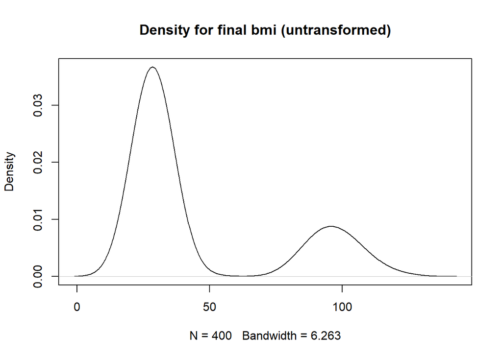

```r
plot(density(weight_control$final_bmi),
     main= "Density for final bmi (untransformed)")
```

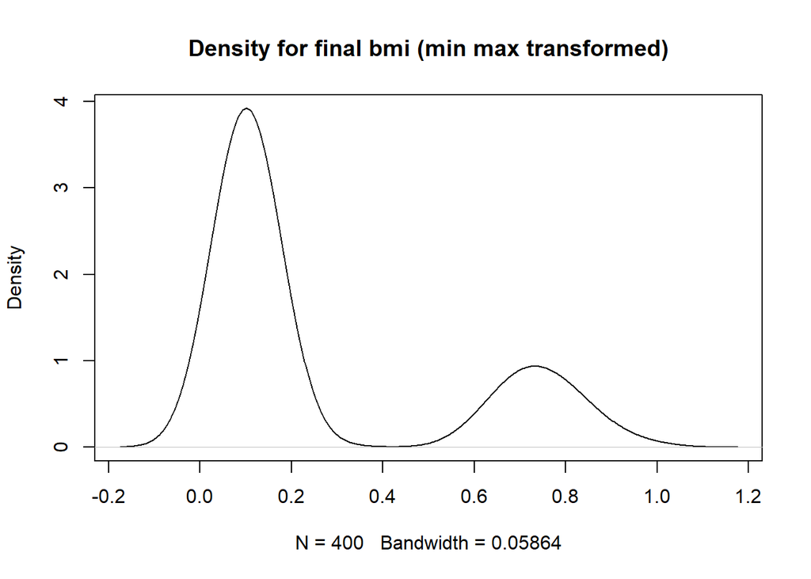

```r
plot(density(weight_control.norm$final_bmi),
     main= "Density for final bmi (min max transformed)")
```

```r
# If we wanted to obtain a dataframe where the columns are minimum and maximum values,
# and the rows the names of the "numerical" columns of "weight_control":

weight_control.minmax<-data.frame(min= rapply(weight_control,
                                      f=min,
                                      classes = "numeric",
                                      deflt = NULL,
                                      how = "unlist"),
                          max=rapply(weight_control,
                                     f=max,
                                     classes = "numeric",
                                     deflt = NULL,
                                     how = "unlist"))
weight_control.minmax
```

```
##                           min        max
## starting_weight_kg 270.208161 325.331426
## final_weight_kg     59.324857 322.561356
## height_m             1.549427   2.005211
## starting_bmi        70.315843 130.094190
## final_bmi           17.604460 124.407777
## delta_weight_kg    -39.078885 261.374147
## delta_bmi          -12.757147 100.778463
```

### 3.8 Wrap-up

> apply: Apply function over the margins of an array.

> lapply: Loop over a list and evaluate a function on each element.

> sapply: Basically the same as lapply but *simplifies/reduces* the result.

> mapply: Multivariate version of lapply

> tapply: Apply a function over subsets of a vector.

> rapply: Apply a function to all elements of an object recursively. The `classes` argument delimits the elements on which the function is going to be applied, based on their class.